# HW Bayes 02

Author

## Instructions

This Homework comes from Chapters 1 & 2 of the [Bayes Rules! Textbook](https://www.bayesrulesbook.com/). You should complete this assignment after having read the full Chapters 1 & 2 in Week 12.

### [Chapter 1 Exercises](https://www.bayesrulesbook.com/chapter-1#exercises):

- 1.6
- 1.8

### [Chapter 2 Exercises:](https://www.bayesrulesbook.com/chapter-2#exercises-1)

- 2.3
- 2.6
- 2.11
- 2.13
- 2.14
- 2.18
- 2.20
- 2.21

```r
library(tidyverse)
library(bayesrules)
library(janitor)
```

## 1.6

#### Part a

> Null: I do NOT get the job, Alternative: I get the job. Assuming I do NOT get the job, what is the probability that I’m qualified for the position?

#### Part b

> What’s the probability I get the job, assuming I am qualified for the position

#### Part c

> The Bayesian question is the more natural one and more likely to be of practical interest.

## 1.8

#### Part a

> Answers will vary: mathematical framework for updating your belief in a hypothesis based on new data

#### Part b

> Bayesian and frequentist frameworks both share a mathematical foundation in probability and involve answering scientific questions with data and accounting for uncertainty in conclusions

## 2.3

#### Part a

> No, the sample size is not fixed so this is not a “number of successes in n trials” scenario.

#### Part b

> Yes, Y ~ binomial(27, 0.9)

#### Part c

> No, the sample size is not fixed so this is not a “number of successes in n trials” scenario.

#### Part d

> No, the outcome is a time, not a discrete number of successes

#### Part e

> No, the outcome is a probability, not a discrete number of successes

#### Part f

> Yes, Y ~ binomial(60, 0.8)

## 2.6

> If L = Sandra likes a restaurant, we want to know P(L|<4 stars), which can be found by P(<4 stars | L)P(L)/P(<4 stars). The piece we don’t have is the marginal probability P(<4 stars).

## 2.11

#### Part a

> *Y*|*π* ∼ *b**i**n**o**m**i**a**l*(6,*π*)

> $f(y\|\pi) = L(\pi\|y) = {6\choose y} \pi^y(1 - \pi)^{6 - y}$

#### Part b

```r
dbinom(x = 4, size = 6, prob = 0.3)
```

```
[1] 0.059535
```

#### Part c

$$Posterior = f(\pi\\y=4) = \frac{f(\pi)f(y = 4\\\pi)}{f(y = 4)}$$

```r
pi <- c(0.3, 0.4, 0.5)
prior <- c(0.25, 0.60, 0.15)
likelihood <- dbinom(4, size = 6, prob = pi)
normalizing <- sum(prior*likelihood)
posterior <- prior*likelihood/normalizing
posterior
```

```
[1] 0.1119214 0.6237141 0.2643645
```

|  | *π* = 0.3 | *π* = 0.4 | *π* = 0.5 |
| --- | --- | --- | --- |
| *f*(*π*\|4) | 0.1119214 | 0.6237141 | 0.2643645 |

## 2.13

#### Part a

> Answers will vary, but 47/80 = 0.5875, so probability from 0.7 should shift down towards 0.6.

#### Part b

```r
pi <- c(0.4, 0.5, 0.6, 0.7)
prior <- c(0.1, 0.2, 0.44, 0.26)
likelihood <- dbinom(47, size = 80, prob = pi)
normalizing <- sum(prior*likelihood)
posterior <- prior*likelihood/normalizing
posterior
```

```
[1] 0.0006491288 0.1135403807 0.8337986003 0.0520118903
```

|  | *π* = 0.4 | *π* = 0.5 | *π* = 0.6 | *π* = 0.7 |
| --- | --- | --- | --- | --- |
| *f*(*π*\|4) | 6.4912877^{-4} | 0.1135404 | 0.8337986 | 0.0520119 |

> Probability from 0.7 shifted down to 0.6. Probability from 0.5 and 0.4 also shifted up to 0.6.

#### Part c

```r
likelihood <- dbinom(470, size = 800, prob = pi)
normalizing <- sum(prior*likelihood)
posterior <- prior*likelihood/normalizing
posterior
```

```
[1] 5.055567e-26 2.646640e-06 9.999974e-01 1.015611e-10
```

> Nearly all the probability is now concentrated on 0.6. The large amount of data swamped the prior, so the posterior is determined almost entirely by the data.

## 2.14

#### Part a

```r
pi <- c(0.15, 0.25, 0.5, 0.75, 0.85)
prior <- c(3, 3, 8, 3, 3)/20
prior
```

```
[1] 0.15 0.15 0.40 0.15 0.15
```

|  | *π* = 0.15 | *π* = 0.25 | *π* = 0.5 | *π* = 0.75 | *π* = 0.85 |
| --- | --- | --- | --- | --- | --- |
| *f*(*π*) | 0.15 | 0.15 | 0.4 | 0.15 | 0.15 |

#### Part b

```r
likelihood <- dbinom(3, 13, pi)
normalizing <- sum(prior*likelihood)
posterior <- prior*likelihood/normalizing
posterior
```

```
[1] 3.552689e-01 4.704645e-01 1.740496e-01 2.151186e-04 1.893492e-06
```

|  | *π* = 0.15 | *π* = 0.25 | *π* = 0.5 | *π* = 0.75 | *π* = 0.85 |
| --- | --- | --- | --- | --- | --- |
| *f*(*π\|y*) | 0.3552689 | 0.4704645 | 0.1740496 | 2.1511865^{-4} | 1.8934923^{-6} |

#### Part c

> The probability shifted to the lower values of *π*. Li learned the bus is less likely to be late than she expected.

## 2.18

```r
set.seed(437)
lactose <- data.frame(pi = c(0.4, 0.5, 0.6, 0.7))

prior <- c(0.1, 0.2, 0.44, 0.26)

lactose_sim <- sample_n(lactose, size = 10000,
                        weight = prior, replace = TRUE)

lactose_sim <- lactose_sim %>%
  mutate(y = rbinom(10000, size = 80, prob = pi))

lactose_sim %>%
  tabyl(pi) %>%
  adorn_totals("row")
```

|  | pi | n | percent |
| --- | --- | --- | --- |
| 1 | 0.4 | 978 | 0.0978 |
| 2 | 0.5 | 2064 | 0.2064 |
| 3 | 0.6 | 4355 | 0.4355 |
| 4 | 0.7 | 2603 | 0.2603 |
| 5 | Total | 10000 | 1.0000 |

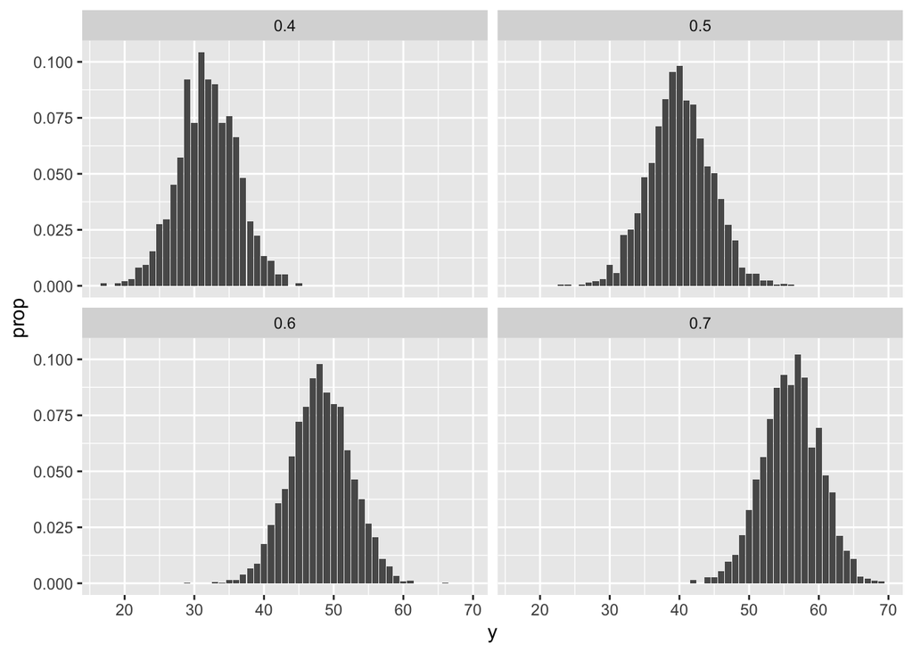

```r
ggplot(lactose_sim, aes(x = y)) +
  stat_count(aes(y = after_stat(prop))) +
  facet_wrap(~ pi)
```

```r
# Focus on simulations with y = 47
data <- lactose_sim %>%
  filter(y == 47)

# Summarize the posterior approximation
data %>%
  tabyl(pi) %>%
  adorn_totals("row")
```

|  | pi | n | percent |
| --- | --- | --- | --- |
| 1 | 0.5 | 56 | 0.11691023 |
| 2 | 0.6 | 398 | 0.83089770 |
| 3 | 0.7 | 25 | 0.05219207 |
| 4 | Total | 479 | 1.00000000 |

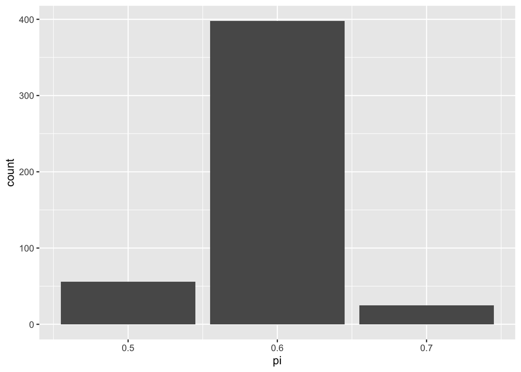

```r
# Plot the posterior approximation
ggplot(data, aes(x = pi)) +
  geom_bar()
```

## 2.20

```r
cat_yes <- data.frame(ID_cat = rbinom(800, size =1,
                                      prob = 0.8),
                      cat = rep("yes", 800))
cat_no <- data.frame(ID_cat = rbinom(9200, size =1,
                                     prob = 0.5),
                      cat = rep("no", 9200))


data <- data.frame(rbind(cat_yes, cat_no))

data %>%
  filter(ID_cat == 1 ) %>%
  count(cat) %>%
  mutate(prob = n/sum(n))
```

| cat | n | prob |
| --- | --- | --- |
| no | 4487 | 0.8770524 |
| yes | 629 | 0.1229476 |

## 2.21

```r
d_yes <- data.frame(ID_have = rbinom(300, size = 1,
                                     prob = 0.93),
                    disease = rep("yes", 300))
d_no <- data.frame(ID_have = rbinom(9700, size = 1,
                                    prob = 0.07),
                   disease = rep("no", 9700))

data <- data.frame(rbind(d_yes, d_no))

data %>%
  filter(ID_have == 1) %>%
  count(disease) %>%
  mutate(prob = n/sum(n))
```

| disease | n | prob |
| --- | --- | --- |
| no | 676 | 0.7085954 |
| yes | 278 | 0.2914046 |

## Reflection prompts

*Respond to each of the following after you have completed all exercises in this assignment*

*(RP1): What were the main concepts covered in this assignment?*

*(RP2): What’s one thing you understand better after completing these exercises?*

*(RP3): What exercise(s) gave you the most trouble? What was difficult about them/where did you get stuck?*